# Notebook

```python
import pymongo
from pymongo import MongoClient

import datetime
import dateutil.parser
import json
import matplotlib
import matplotlib.pyplot as plt
import numpy as np
import os
import pandas as pd
import requests
from scipy.misc import imread
from StringIO import StringIO
import math
```

```python
SHOW_TESTS = True

personNumber = 304
```

```python
%matplotlib inline
plt.rcParams['figure.figsize'] = (20, 10)
```

Load the data from the json into the db from the terminal (not the mongo terminal)

`mongoimport --db test --collection detections --file Desktop/data/200916_2_3.json --jsonArray`

```python
reprocessTheFile = False #almost certaintly should be false, a gig of text takes a while
if reprocessTheFile:
    import fileinput
    path="/home/ben/Desktop/data/200916_2_3.json"
    i=0
    num_lines = sum(1 for line in open(path))
    print num_lines
    for line in fileinput.input(path, inplace=1): # single filename string
        start = "[" if i == 0 else ""
        end   = "," if i != num_lines - 1 else "]"
        print start+line.rstrip()+end
        i+=1
```

```python
# Connection to Mongo DB
try:
    conn=pymongo.MongoClient()
    print "Connected successfully!!!"
except pymongo.errors.ConnectionFailure, e:
   print "Could not connect to MongoDB: %s" % e
conn
```

```
Connected successfully!!!
```

```
MongoClient(host=['localhost:27017'], document_class=dict, tz_aware=False, connect=True)
```

```python
db = conn.test
db
```

```
Database(MongoClient(host=['localhost:27017'], document_class=dict, tz_aware=False, connect=True), u'test')
```

```python
#collection
detections = db.detections
detections
```

```
Collection(Database(MongoClient(host=['localhost:27017'], document_class=dict, tz_aware=False, connect=True), u'test'), u'detections')
```

```python
detections.find_one()
```

```
{u'_id': ObjectId('57e0b444076239610ace7f67'),
 u'agentId': u'0000000081d28129',
 u'major': 1,
 u'minor': 297,
 u'rssi': -66,
 u'time': datetime.datetime(2016, 9, 20, 4, 0, 0, 38000),
 u'tx': -58,
 u'uuid': u'17520757a1412b175c03687a7102a104'}
```

```python
#get just the data we care about, not the rest of it.
d = list(detections.find({u'minor':personNumber}, { u'agentId': 1, u'time': 1, u'rssi': 1, u'_id': 0 }))
df = pd.DataFrame.from_dict(d)
df.head()
```

|  | agentId | rssi | time |
| --- | --- | --- | --- |
| 0 | 0000000081d28129 | -79 | 2016-09-20 04:00:02.279 |
| 1 | 000000002f9f3fae | -57 | 2016-09-20 04:00:00.370 |
| 2 | 000000002f9f3fae | -61 | 2016-09-20 04:00:01.324 |
| 3 | 000000002f9f3fae | -57 | 2016-09-20 04:00:03.227 |
| 4 | 000000002f9f3fae | -48 | 2016-09-20 04:00:04.178 |

```python
print df.shape
```

```
(28168, 3)
```

```python
#get the data about the base stations from the google spreadsheet
baseDataCSVaddress = "https://docs.google.com/spreadsheets/d/167pxh_NRq5e9sQV9Zb8Z-Q-kdN7Zy9FCzCp47eVXTuE/pub?gid=1446311565&single=true&output=csv"
r = requests.get(baseDataCSVaddress)
data = r.content
baseData = pd.read_csv(StringIO(data))

#only keep the columns we care about
baseData = baseData.ix[:,0:5]
baseData = baseData[baseData.agentId > 0] #not really sure how this works, maybe failure is falsy?
baseData.head(3)
```

|  | agentId | agentName | location | x | y |
| --- | --- | --- | --- | --- | --- |
| 0 | 00000000e5bd0ae9 | Ace | Citizen | 2953.206017 | 14427.458860 |
| 1 | 000000006c1a3b5a | Alfa | Between citizen and library | 3323.405966 | 9086.502512 |
| 2 | 0000000020294bbd | Beer | Sample Library | 3313.076869 | 2665.631392 |

```python
bigdf = pd.merge(df,baseData,on=["agentId"])
# rescale rssi between 0 and max in positive numbers. Bigger number means more powerful signal
minPower = min(bigdf.rssi)
bigdf['rssiAdj'] = bigdf.rssi - minPower
bigdf['xWeighted'] = (bigdf.x * bigdf.rssiAdj)/bigdf.rssiAdj.mean() #dead simple. Will probably need a function to handle weighting
bigdf['yWeighted'] = (bigdf.y * bigdf.rssiAdj)/bigdf.rssiAdj.mean()
bigdf.head()
```

|  | agentId | rssi | time | agentName | location | x | y | rssiAdj | xWeighted | yWeighted |
| --- | --- | --- | --- | --- | --- | --- | --- | --- | --- | --- |
| 0 | 0000000081d28129 | -79 | 2016-09-20 04:00:02.279 | Sugar | Principals Table (South) | 56755.95339 | -11320.44941 | 26 | 52910.935117 | -10553.528369 |
| 1 | 0000000081d28129 | -77 | 2016-09-20 04:00:03.230 | Sugar | Principals Table (South) | 56755.95339 | -11320.44941 | 28 | 56981.007049 | -11365.338244 |
| 2 | 0000000081d28129 | -66 | 2016-09-20 04:00:04.180 | Sugar | Principals Table (South) | 56755.95339 | -11320.44941 | 39 | 79366.402675 | -15830.292554 |
| 3 | 0000000081d28129 | -82 | 2016-09-20 04:00:06.087 | Sugar | Principals Table (South) | 56755.95339 | -11320.44941 | 23 | 46805.827219 | -9335.813557 |
| 4 | 0000000081d28129 | -79 | 2016-09-20 04:00:10.866 | Sugar | Principals Table (South) | 56755.95339 | -11320.44941 | 26 | 52910.935117 | -10553.528369 |

# TODO: move all functions to one place, write tests, apply the new functions to the experiments, write better descriptions of the experiments, write future experiments, visualise as vector blocks,

```python
def timeStats(df, showprint=True, actuallyReturn=True):
    #This gives us an idea of the time domain that the data we have is interested in.
    if showprint or actuallyReturn:
        minT = df.time.min()
        maxT = df.time.max()
        rangeT = maxT-minT
    else:
        print "are you mental, why are you calling this with everything turned off?"
    if showprint:
        print minT,   "First Recording in this set"
        print maxT,   "Last Recording in this set"
        print rangeT, "Range covered"
    if actuallyReturn:
        return (minT,maxT,rangeT)

if SHOW_TESTS:
    timeStats(bigdf,showprint=False, actuallyReturn=False)
    print
    timeStats(bigdf, actuallyReturn=False)
    print timeStats(bigdf, showprint=False), "\n"
    timeStats(bigdf)
```

```
are you mental, why are you calling this with everything turned off?

2016-09-20 04:00:00.302000 First Recording in this set
2016-09-20 04:59:59.286000 Last Recording in this set
0 days 00:59:58.984000 Range covered
(Timestamp('2016-09-20 04:00:00.302000'), Timestamp('2016-09-20 04:59:59.286000'), Timedelta('0 days 00:59:58.984000'))

2016-09-20 04:00:00.302000 First Recording in this set
2016-09-20 04:59:59.286000 Last Recording in this set
0 days 00:59:58.984000 Range covered
```

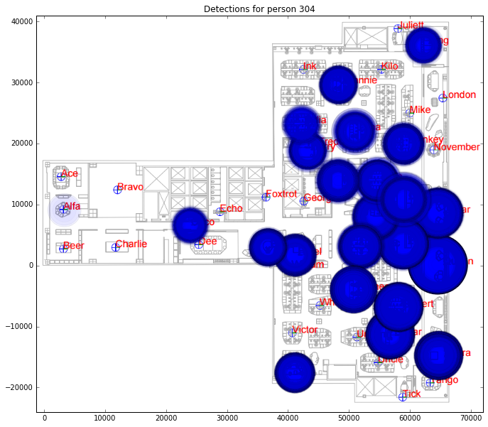

```
2016-09-20 04:00:00.302000 First Recording in this set
2016-09-20 04:59:59.286000 Last Recording in this set
0 days 00:59:58.984000 Range covered
```

```python
plt.title('Detections for person {}'.format(personNumber))
img = imread("map.png")
plt.scatter(bigdf.x, bigdf.y, zorder=1, s=abs(bigdf.rssiAdj)*100, alpha=0.02)
plt.imshow(img, zorder=0, extent=[-1300, 72000, -24000, 41000])
#                                [left,  right, bottom, top  ]
plt.show()
timeStats(bigdf, actuallyReturn=False)
```

All detections in this time period. Circle radius shows signal strength.

# Experiments

## Functions for experiments

```python
def timeCropDf(df, startTime, windowLength):
    if type(startTime) is str:
        startTime = dateutil.parser.parse(startTime)
    delta = datetime.timedelta(seconds=windowLength)
    endTime = startTime + delta
    return df[(df.time > startTime) &
              (df.time < endTime)]

def makeGif(fromPath, fileName, stepSize, forReal=True, chatty=True):
    #send a system command to make this into a gif. See https://community.linuxmint.com/tutorial/view/1118
    command="convert -delay 20 -loop 0 {} {}{}.gif".format(fromPath, fileName, stepSize)
    if chatty:
        print command
    if forReal:
        os.system(command)

def clearFolder(path):
    mydir = os.getcwd()+path
    map( os.unlink, [os.path.join( mydir,f) for f in os.listdir(mydir)] )
```

## Common things

We query the data for this person from the database. (304 is me, in case you were wondering). It's then pushed into a function that turns it into an animation.

It does this by taking time windows out of the data. It currently steps along by one time period as a time. Future ones will advance by less than a time period to see if this makes it more stable.

```python
ntileAdjRSSI = bigdf.rssiAdj.quantile(.7)
topN = 3

def timeSliced(startTime, windowLength, df):

    df = timeCropDf(df, startTime, windowLength)
    all_centroidweighted = {"x":df.xWeighted.mean(), "y":df.yWeighted.mean()}
    all_centroid         = {"x":df.x.mean(),         "y":df.y.mean()}

    #specific trim for this top N.
    topNdf = df.sort("rssiAdj", ascending=0)[:topN]
    topN_centroidweighted = {"x":topNdf.xWeighted.mean(), "y":topNdf.yWeighted.mean()}
    topN_centroid         = {"x":topNdf.x.mean(),         "y":topNdf.y.mean()}

    #specific trim for this top Ntile.
    topNtiledf = df[df.rssiAdj > ntileAdjRSSI]
    topNtile_centroidweighted = {"x":topNtiledf.xWeighted.mean(), "y":topNtiledf.yWeighted.mean()}
    topNtile_centroid         = {"x":topNtiledf.x.mean(),         "y":topNtiledf.y.mean()}


    delta = datetime.timedelta(seconds=windowLength)
    title = "Detections for person {} from {} to {} in steps of {} seconds".format(personNumber,
                                                                                   startTime,
                                                                                   startTime+delta,
                                                                                   delta.total_seconds())
    plt.title(title)

    # Plot all the detections onto the map as pale circles
    plt.scatter(df.x, df.y, zorder=1, s=abs(df.rssiAdj)*100, alpha=0.2)

    #     b: blue
    #     g: green
    #     r: red
    #     c: cyan
    #     m: magenta
    #     y: yellow
    #     k: black
    #     w: white

    plt.scatter(all_centroid["x"],         all_centroid["y"],         c="g", zorder=2, s=100)
    plt.scatter(all_centroidweighted["x"], all_centroidweighted["y"], c="r", zorder=2, s=100)
    plt.plot([all_centroid["x"], all_centroidweighted["x"]],
             [all_centroid["y"], all_centroidweighted["y"]], 'k-', lw=1) #line between centroid and weighted centroid

    plt.scatter(topN_centroidweighted["x"], topN_centroidweighted["y"], c="m", zorder=2, s=100)
    plt.scatter(topN_centroid["x"],         topN_centroid["y"],         c="y", zorder=2, s=100)

    plt.scatter(topNtile_centroidweighted["x"], topNtile_centroidweighted["y"], c="c", zorder=2, s=100)
    plt.scatter(topNtile_centroid["x"],         topNtile_centroid["y"],         c="k", zorder=2, s=100)

    plt.legend(["line",
                "detections",
                "centroid",
                "centroid weighted",
                "top N_centroid weighted",
                "top N_centroid",
                "top Ntile centroid weighted",
                "top Ntile centroid"],
               loc=2, #legend loc='upper left'
               scatterpoints=1,
               frameon=False
               )

    #put the image on the graph as an underlay
    img = imread("map.png")
    plt.imshow(img, zorder=0, extent=[-1300, 72000, -24000, 41000])
    #                                [left,  right, bottom, top  ]

    # plt.show() #don't show, we need to save
    plt.savefig("frames/dbAnim/foo"+str(startTime)+".png", bbox_inches='tight')
    plt.clf()


ts=timeStats(bigdf)
timeSize = ts[2]
stepSize = 5 #in seconds
steps = int(timeSize.total_seconds() / stepSize)
print "will make",steps,"frames"
clearFolder('/frames/dbAnim/')
```

```
2016-09-20 04:00:00.302000 First Recording in this set
2016-09-20 04:59:59.286000 Last Recording in this set
0 days 00:59:58.984000 Range covered
will make 719 frames
```

```python
#this takes quite a long time if you have a lot of frames
for i in range(steps):
    s = ts[0] + datetime.timedelta(seconds=stepSize*i)
    timeSliced(s,
               stepSize,
               bigdf)

makeGif("frames/dbAnim/*.png", "dbAnim", stepSize)
```

```
convert -delay 20 -loop 0 frames/dbAnim/*.png dbAnim5.gif
```

[figure not shown]

# very simple classifiers

The animation above is all the stuff I've been trying, all in one place.

Each frame shows all the detections that happen in this time period. I'll call this a window.

The pale cirlces are detections. They are darker when there are a lot of detections in this time window. The size is the strength of the detection.

The rest of the dots show the results the the very naive ways that we've tried so far to convert the big chunk of data that is one window into a location.

$$f(detections) = classifier \mapsto (x,y)$$

The idea of the classifier is that given some detections, it should give you a position in space. A better clasifier will give you more reliable positions. (Where reliable means that it has a better corespondance with where someone actually is.)

## Centroid vs weighted centroid

The centroid is just based on a shape defined by the vertices of the base stations that detect in the time window.

The weighted centroid means that the resulting dot is affected more by strong detections than weak ones.

- Green = centroid of the detections
- Red = weighted centroid of detections (weighted on signal strength) *I'm not convinced that I've calculated the weighted centroids correctly.*

The weighted centroids for the next two tries don't seem to be working. I don't think we're missing much.

## Strongest n

Let's try Tiara's model of taking onny the strongest n detections in a period.

This is the data trimmed to just the 3 strongest detections in each time period.

That's much more stable, but in any longish duration the odds are that the same base is going to have the strongest detections. (This being me, there's a pretty good chance that I am actually sitting right there.)

So that doesn't seem that useful. How about only taking above average strength detections?

# Top percentile

What if we only look at the strongest n% of detections? This ought to throw out distant detections. In this case, the strongest 30% of detections from a window.

This approach doesn't seem to be working. With only one base station selected there is very limited scope for a more subtle understanding of where people are.

Let's try a different way of looking at the data.

```python
def vectoriseDetectionsByWindow(startTime, windowLength, df):

    df = timeCropDf(df, startTime, windowLength)
    return {"data":df['rssiAdj'].groupby(df['agentName']).mean().to_dict(),
            "startTime":startTime,
            "windowLength":windowLength}


ts=timeStats(bigdf)
timeSize = ts[2]
stepSize = 5 #in seconds
steps = int(timeSize.total_seconds() / stepSize)
print "will make",steps,"frames"

vectors = []
for i in range(steps):
    s = ts[0]+datetime.timedelta(seconds=stepSize*i)
    vectors.append( vectoriseDetectionsByWindow(s,
                    stepSize,
                    bigdf)
                   )

vData = [d["data"] for d in vectors]
newDF = pd.DataFrame.from_dict(vData)#.fillna(value=0)
newDF["startTime"] = [d["startTime"] for d in vectors]
newDF["windowLength"] = [d["windowLength"] for d in vectors]
newDF = newDF.sort("startTime")
# newDF.head()
```

```
2016-09-20 04:00:00.302000 First Recording in this set
2016-09-20 04:59:59.286000 Last Recording in this set
0 days 00:59:58.984000 Range covered
will make 719 frames
```

```python
width = newDF.shape[1]
newDF = newDF[newDF.columns[0:width-2]]
```

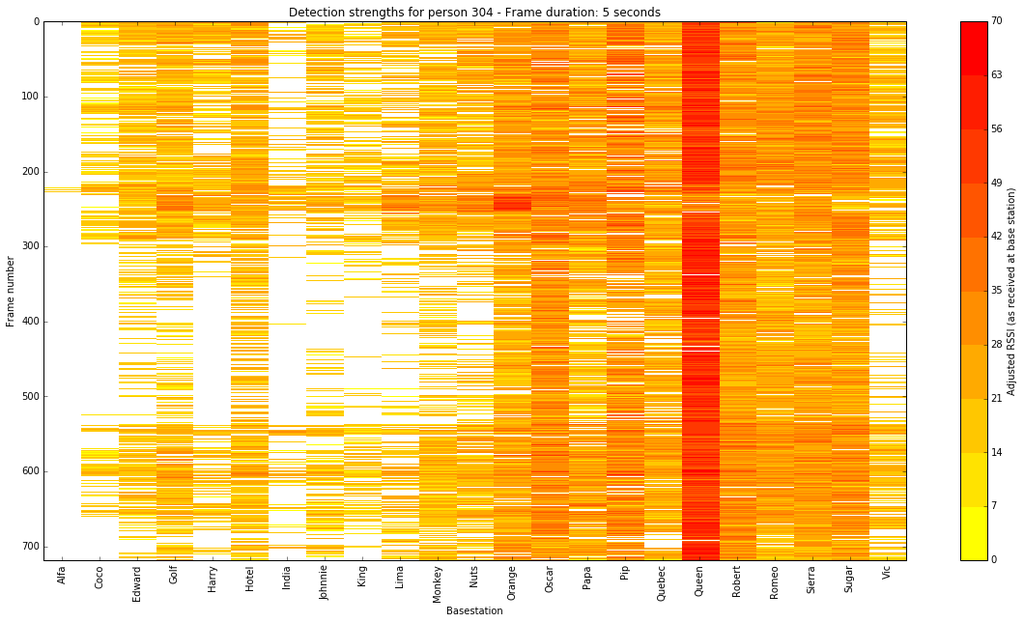

```python
# make values from -5 to 5, for this example
zvals = newDF

# make a color map of fixed colors
# colourMaps = ["autumn","bone","cool","copper","flag","gray","hot","hsv","jet","pink","prism","spring","summer","winter","spectral"]
start = newDF.min().min()
stop  = newDF.max().max() #returns a series that then needs to be searched again
step  = math.floor( (stop-start)/10 )
bounds= np.arange(start, stop, step)

for mapName in ["autumn_r"]:
    cmap=plt.get_cmap(mapName)
    norm = matplotlib.colors.BoundaryNorm(bounds, cmap.N)

    # tell imshow about color map so that only set colors are used
    img = plt.imshow(zvals,
                     interpolation='nearest',
                     cmap=cmap,
                     norm=norm,
                     aspect='auto')

    # make a color bar
    plt.colorbar(img,
                 cmap=cmap,
                 norm=norm,
                 boundaries=bounds,
                 ticks=bounds,
                 label='Adjusted RSSI (as received at base station)')

    x = np.arange(0, newDF.shape[1], 1)
    labels = list(newDF.columns)
    plt.xticks(x, labels, rotation='vertical')

    plt.title('Detection strengths for person {} - Frame duration: {} seconds'.format(personNumber, stepSize))
    plt.xlabel("Basestation")
    plt.ylabel("Frame number")
    plt.show()
```